# Money and Success in Football

Does Financial Strength Predict Points Per Game? A Generalized Additive Model *Sports Economics Seminar, Summer Semester 2026

Md. Muktadir

July 21, 2026

# Abstract

# 1 Introduction

## 1.1 Why Does This Question Matter?

The five major European football leagues (the English Premier League, Spanish La Liga, German Bundesliga, Italian Serie A, and French Ligue 1) collectively generate over 18 billion euros in annual revenue, with squad transfer spending exceeding 12 billion euros in recent seasons. With this much money flowing through the sport, a natural and important question arises: does financial investment actually buy sporting success, or can a well organised, under funded club systematically compete at the top level?

This question reaches beyond football itself. Competitive balance policy is one reason it matters: UEFA introduced Financial Fair Play specifically to prevent the wealthiest clubs from buying their way to dominance, and if money truly determines outcomes, such policies become more important, not less. Fan engagement is a second reason: if league tables are financially predetermined, some of the drama of competition is lost for supporters of smaller clubs. Sports economics theory is a third reason: understanding how resource advantages translate into tournament outcomes informs similar questions across every competitive sport with unequal team budgets.

## 1.2 The Analytical Approach Taken in This Report

Two methodological choices shape everything that follows, and both are set out here at the start rather than introduced partway through.

The first choice is the outcome variable. Rather than final league position (a ranking from first to last), this report treats points per game as the outcome to be explained. League position is what statisticians call an ordinal variable: it tells us that a team finished third and not fourth, but it says nothing about how large that gap actually was. A club that misses the title by a single point looks identical, position-wise, to one that misses it by twenty. Points per game is a continuous, evenly spaced quantity instead: the difference between 1.50 and 1.60 points per game always means the same thing, regardless of where in the table a team sits. A continuous outcome is generally the better fit for the regression methods used throughout this report, while a purely ordinal outcome like raw position is better suited to specialised rank based methods. Points per game also solves a second, more practical problem: because the Bundesliga plays a 34 match season while the other four leagues play 38 matches, raw points totals are not directly comparable across leagues. Dividing by matches played removes that distortion (this is explained further in the Data section).

The second choice is the functional form connecting financial strength to performance, that is, the shape of the mathematical relationship between the two. Earlier stages of this project fitted a fixed, curved shape (a quadratic term) chosen in advance. This report instead fits a generalized additive model, which allows the data to determine how much the relationship should curve and where, rather than committing to one particular curved shape before looking at the data. Both of these choices, the outcome variable and the modelling approach, are explained in full, plain language detail in the Methodology section below; they are simply stated here as the analytical plan followed throughout the rest of this report.

## 1.3 What We Set Out to Answer

This report addresses three related questions using ten years of data from all five top tier European leagues. First, direction and strength: is there a statistically meaningful relationship between a club’s financial rank within its league and how many points per game it earns, and how strong is that relationship? Second, model form: does a straight line relationship capture the pattern in the data, or is a more flexible, curved relationship needed, and does the data support a smoothly varying effect beyond what a single fixed curve could represent? Third, exceptions: which clubs defy the financial hierarchy, and how statistically unusual are they under this revised approach?

# 2 The Data We Used

## 2.1 Sources and Sample

The dataset combines two sources. ESPN FC provided final league standings and total points won for all five leagues across the 2015-16 through 2024-25 seasons. Transfermarkt provided squad market values, the estimated total transfer market worth of all players in a squad, at the start of each season. After merging these sources and removing rows with missing key values, the working dataset contains 976 team-season observations; every club that played a full season in one of the five leagues during the study period appears once per season. One Serie A observation, SPAL in 2017-18, had a missing market value in the original source due to a merge failure between the standings and market value data; the correct value of 63.55 million euros was verified directly on Transfermarkt and inserted, raising N from 975 to 976.

## 2.2 Financial Rank: Why Rank Instead of Raw Value

Squad market values cannot be compared directly across leagues. A squad worth 300 million euros is the richest in Ligue 1 but only the fifth-richest in the Premier League, since the Premier League’s overall spending is much higher. Comparing raw euro values across leagues would be an apples to oranges comparison. The solution used throughout this project is Financial Rank: each squad is ranked from 1 (the most valuable squad) to the number of clubs in that league that season, separately within each league and season. Financial Rank 1 always means “the wealthiest club in this specific league this specific season,” regardless of whether that squad is worth 600 million euros or 150 million euros. This within-league ranking is what makes it possible to pool all five leagues into a single analysis.

## 2.3 Points Per Game: Why Divide by Matches Played

The outcome variable in this report, points per game, is total points earned in a season divided by matches played that season. This division matters because not every league plays the same number of matches: the Bundesliga has 18 clubs and a 34 match season, while the other four leagues have 20 clubs and a 38 match season. A club in a 38 match league can accumulate up to 114 points (38 wins at 3 points each), while a club in the 34 match Bundesliga can accumulate at most 102 points. Comparing raw point totals across these two league formats would systematically and unfairly penalise Bundesliga clubs. Dividing by matches played converts every team-season onto the same scale (points earned per match played), making comparisons across league formats fair for the first time.

## 2.4 Descriptive Statistics

| League | N | Mean position | Mean squad value (million euros) | Mean points | Pearson r (FR vs. position) |
| --- | --- | --- | --- | --- | --- |
| All leagues (combined) | 976 | 10.28 | 277.7 | 50.71 | 0.81 |
| Bundesliga | 180 | 9.50 | 237.2 | 46.80 | 0.78 |
| La Liga | 200 | 10.50 | 256.7 | 52.02 | 0.79 |
| Ligue 1 | 196 | 10.32 | 184.7 | 49.69 | 0.79 |
| Premier League | 200 | 10.50 | 458.0 | 52.51 | 0.80 |
| Serie A | 200 | 10.50 | 245.8 | 52.11 | 0.89 |

Table 1: Sample size, average outcomes, and the Financial Rank to position correlation, by league and combined.

The “All leagues (combined)” row covers the full sample. Squad values vary substantially by league (the Premier League’s average is considerably higher than Ligue 1’s, for example), while the raw correlation between Financial Rank and final position already exceeds 0.78 in every single league before any model is fitted, reaching 0.89 in Serie A. This is a first hint, well before the modelling begins, that financial strength is a powerful predictor of sporting outcomes in every one of the five leagues studied.

# 3 Methodology: From a Straight Line to a Learned Curve

This report builds its model in three deliberate steps, each one relaxing an assumption made by the step before it. Each step is explained in full before the next one is introduced, so that a reader who has never encountered a generalized additive model can follow the reasoning from first principles.

## 3.1 Step 1: A Straight Line (Linear Specification)

The simplest possible model is a straight line: predicted points per game equals some baseline value, plus a fixed amount for every step down the financial hierarchy. This kind of relationship is called linear because, if plotted, it forms a single straight line. A linear model implies a strong assumption: that the penalty for being one Financial Rank worse is exactly the same everywhere, whether we are comparing the wealthiest club to the second wealthiest, or the fourteenth wealthiest to the fifteenth. There is no reason to expect that assumption to be true in general, but it is the natural starting point and a useful baseline against which to judge whether anything more complex is actually needed.

**Model equation:**

$$\text{PPG}_i = \beta_0 + \beta_1 \cdot
\text{FR}_i + \varepsilon_i$$

where $\text{PPG}_i$ is points per game for club-season $i$, $\text{FR}_i$ is that club-season’s Financial Rank, $\beta_0$ is the intercept (the predicted points per game at Financial Rank zero, a reference point rather than an observed case), $\beta_1$ is the slope (the change in predicted points per game for every one-rank drop in Financial Rank, expected to be negative), and $\varepsilon_i$ is the residual, the gap between a club’s actual and predicted points per game left unexplained by the line.

**R implementation:**

```r
lin_ppg <- lm(Points_Per_Game ~ Financial_Rank, data = model_df_ppg)
```

`lm()` fits the equation above by ordinary least squares, choosing $\beta_0$ and $\beta_1$ to minimise the sum of squared residuals; `Points_Per_Game ~ Financial_Rank` is R’s formula shorthand for “regress points per game on Financial Rank.”

## 3.2 Step 2: A Fixed Curve (Quadratic Specification)

Earlier stages of this project (documented in full in the Appendix) established that the straight line assumption does not hold: the penalty for a worse financial rank is larger at the top of the hierarchy (between the first and second richest clubs, for example) than at the bottom (between the nineteenth and twentieth richest). To capture that pattern, a quadratic term was added: alongside Financial Rank itself, the model also includes Financial Rank multiplied by itself (Financial Rank squared). A squared term lets the fitted line bend into a single smooth curve, specifically a parabola, rather than staying straight. This is a genuine improvement, but it still commits to one particular curved shape in advance: a parabola always has exactly one bend, always symmetric on either side. There is no substantive reason to expect that the true relationship between financial rank and performance takes exactly this shape, rather than, for instance, levelling off among mid table clubs before steepening again near the bottom of the table.

**Model equation:**

$$\text{PPG}_i = \beta_0 + \beta_1 \cdot
\text{FR}_i + \beta_2 \cdot \text{FR}_i^2 + \varepsilon_i$$

where $\text{PPG}_i$, $\text{FR}_i$, $\beta_0$, $\beta_1$, and $\varepsilon_i$ carry the same meaning as in Step 1, and $\beta_2$ is the coefficient on Financial Rank squared, the new term that lets the fitted relationship bend into a parabola rather than stay straight. This is the specification referred to as Model H elsewhere in this report.

**R implementation:**

```r
quad_ppg <- lm(Points_Per_Game ~ Financial_Rank + I(Financial_Rank^2),
                data = model_df_ppg)
```

`I(Financial_Rank^2)` tells R to treat Financial Rank squared as its own predictor column (the `I()` wrapper prevents `^` from being read as formula shorthand); `lm()` then estimates $\beta_0$, $\beta_1$, and $\beta_2$ jointly by ordinary least squares, exactly as in Step 1 but with one additional term.

## 3.3 Step 3: A Learned Curve (Generalized Additive Model)

The final step, and the model adopted for the remainder of this report, relaxes the quadratic assumption entirely. A generalized additive model (commonly abbreviated GAM) replaces the fixed squared term with a smooth term: a flexible curve built from a combination of simpler basis functions, whose exact shape is estimated from the data rather than chosen by the analyst in advance. In plain terms, instead of telling the model “the relationship must be a parabola” and asking it to find the best parabola, a generalized additive model is told “find whatever smooth curve fits best,” and it is free to produce a shape that bends more in one place than another, flattens out, or steepens, wherever the data actually support that pattern. The model fitted here is points per game explained by a smooth function of Financial Rank, estimated using the mgcv package in R with restricted maximum likelihood smoothing parameter selection (a standard, data driven method for choosing how flexible the smooth curve is allowed to be, balancing fit against overfitting). This preserves the core intuition behind the quadratic term, that the effect of financial rank is not constant, while removing the requirement that the non-constant effect take one specific, predetermined shape.

**Model equation:**

$$\text{PPG}_i = \beta_0 + f(\text{FR}_i)
+ \varepsilon_i, \qquad
f(\text{FR}) = \sum_{k=1}^{K} b_k(\text{FR}) \, \gamma_k$$

where $\text{PPG}_i$, $\text{FR}_i$, $\beta_0$, and $\varepsilon_i$ carry the same meaning as in Steps 1 and 2, and $f(\cdot)$ is the smooth term: an unspecified curve built from $K$ spline basis functions $b_k(\cdot)$ with weights $\gamma_k$ estimated from the data, rather than a term whose shape (straight line, parabola) is fixed in advance. A penalty on how much $f(\cdot)$ is allowed to wiggle is controlled by a smoothing parameter, chosen automatically by restricted maximum likelihood (REML) so that the curve’s flexibility is set by the data rather than by the analyst.

**R implementation:**

```r
gam_ppg <- mgcv::gam(Points_Per_Game ~ s(Financial_Rank), data = model_df_ppg,
                      method = "REML")
```

`s(Financial_Rank)` is the `mgcv` syntax for “fit a smooth term on Financial Rank” rather than a single linear or quadratic coefficient; `method = "REML"` selects the smoothing-parameter estimation method described above. Everything downstream in this report (fitted values, residuals, outlier flags) is computed from this fitted `gam_ppg` object.

# 4 Core Results

## 4.1 The Three-Way Comparison

The table below compares all three specifications from the Methodology section: the linear model, the quadratic model (labelled Model H throughout this project and its earlier reports), and the generalized additive model, all fitted with points per game as the outcome and Financial Rank as the only predictor. Three columns need explaining before the numbers are presented. The first is R squared or deviance explained: for the two ordinary regression models this is R squared, the share of the variation in points per game the model accounts for, from 0 (none) to 1 (all of it); for the generalized additive model the comparable quantity is deviance explained, which measures the same idea (share of variation accounted for) but is computed differently because a GAM’s predictions do not come from a simple sum of fixed coefficients. The second column is AIC (Akaike Information Criterion), a score that rewards a model for fitting the data well but penalises it for using unnecessary complexity; lower AIC indicates a better trade-off between accuracy and simplicity, and AIC is only meaningful for comparing models fitted to the exact same outcome variable and data, which is the case for all three rows here. The third column, effective degrees of freedom, is reported only for the generalized additive model and is explained fully below the table.

| Model | N | R squared / deviance explained | AIC | Effective degrees of freedom |
| --- | --- | --- | --- | --- |
| Quadratic (Model H) | 976 | 0.6958 | 100.10 |  |
| Linear | 976 | 0.6524 | 228.50 |  |
| Generalized additive model | 976 | 0.7065 | 75.32 | 6.303 |

Table 2: Comparison of the linear, quadratic, and generalized additive specifications for points per game, from this report’s underlying GAM revision output.

## 4.2 Effective Degrees of Freedom, Explained

Effective degrees of freedom (edf) measures how much curvature the smooth term actually used, on a scale where 1 means the smooth term behaved exactly like a straight line, and larger values mean progressively more flexible, wigglier curves. If the effective degrees of freedom here had come out close to 1, that would mean the extra flexibility of a generalized additive model bought nothing beyond what the simple linear model already achieved. Instead, the effective degrees of freedom is 6.3, well above 1, which confirms there is genuine, non-trivial curvature in the relationship between financial rank and points per game that a straight line would completely miss. At the same time, 6.3 is also more nuanced than the two degrees of freedom implied by a fixed quadratic term: a quadratic curve can only bend once, in one direction, whereas a smooth term with an effective degrees of freedom around 6 can accommodate a more gradual, multi-part curve, for example a steep early drop among the wealthiest clubs followed by a flatter, more gradual decline among the rest. In short, the data support meaningfully more curvature than a single parabola allows, without requiring anywhere near the flexibility of an unconstrained, highly irregular curve.

## 4.3 The Fitted Curve and Its Confidence Band

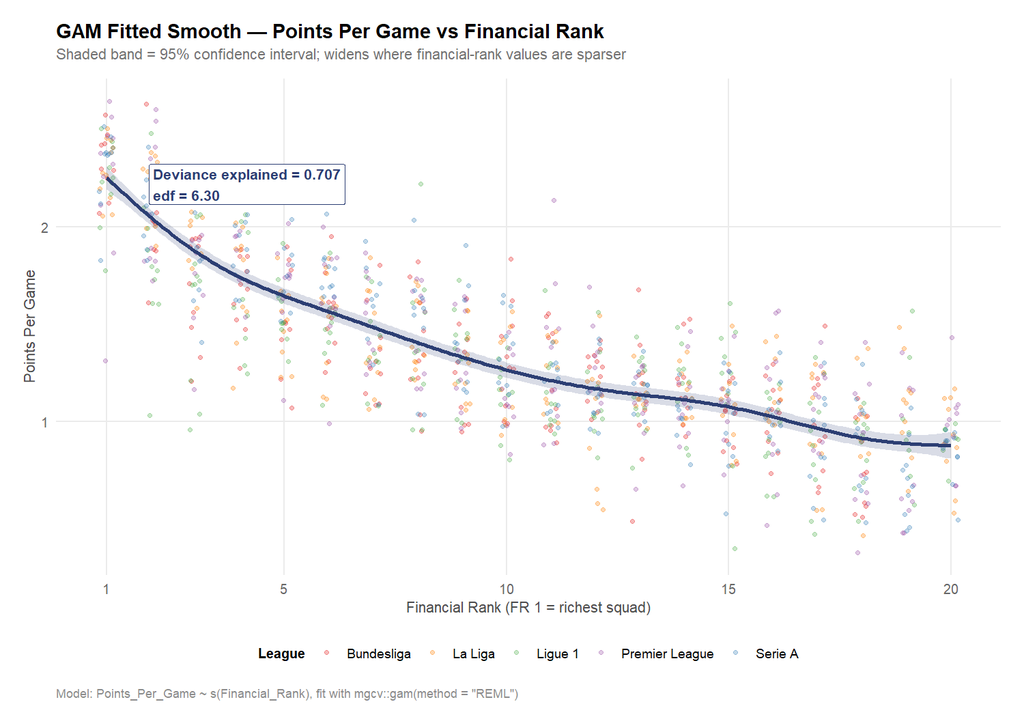

The generalized additive model’s fitted smooth term (dark line) and 95 percent confidence band (shaded), plotted against Financial Rank, with individual team-seasons jittered by league in the background.

The shaded region around the fitted curve is a confidence band, the two-dimensional version of a confidence interval. A confidence interval is a range of values, calculated from the data, that is expected to contain the true underlying value with a stated degree of certainty, conventionally 95%; a confidence band simply plots that same range at every point along the curve, so its width shows exactly where the estimate is precise and where it is uncertain. Reading the figure: points per game falls steeply as Financial Rank worsens from first to roughly tenth, then flattens into a shallower decline for the remaining, less wealthy clubs, exactly the kind of multi-part curvature the effective degrees of freedom result predicted above.

# 5 Outlier Analysis

## 5.1 What a Residual Is, and Why It Is Useful

Once a model has been fitted, every team-season has a predicted value (what the model expects that club to earn in points per game, given its Financial Rank) and an actual value (what the club actually earned). The difference between the two, actual minus predicted, is called the residual. A residual close to zero means the model predicted that club well. A large positive residual means a club earned far more points per game than its finances predicted, an overperformer. A large negative residual means a club earned far fewer points per game than its finances predicted, an underperformer. Looking at the most extreme residuals is a systematic way of finding the clubs whose season cannot be explained by money alone, exactly the stories that make football interesting.

## 5.2 The Ten Largest Overperformers and Underperformers

Team

Season

League

FR

Actual PPG

Pred. PPG

Residual

Leicester City

2015-2016

Premier League

11

2.132

1.211

0.921

Lens

2022-2023

Ligue 1

8

2.211

1.406

0.805

Clermont Foot

2022-2023

Ligue 1

19

1.553

0.887

0.665

Atalanta

2019-2020

Serie A

8

2.053

1.406

0.647

Bayer Leverkusen

2023-2024

Bundesliga

2

2.647

2.049

0.598

Granada

2019-2020

La Liga

19

1.474

0.887

0.586

Atalanta

2016-2017

Serie A

9

1.895

1.331

0.563

1. FC Union Berlin

2022-2023

Bundesliga

10

1.824

1.266

0.558

Liverpool

2019-2020

Premier League

2

2.605

2.049

0.556

Sheffield United

2019-2020

Premier League

20

1.421

0.877

0.544

Table 3: Top 10 overperformers under the generalized additive model, sorted by residual size (largest positive first). FR is Financial Rank; PPG is points per game.

| Team | Season | League | FR | Actual PPG | Pred. PPG | Residual |
| --- | --- | --- | --- | --- | --- | --- |
| Lyon | 2019-2020 | Ligue 1 | 2 | 1.053 | 2.049 | -0.996 |
| Chelsea | 2015-2016 | Premier League | 1 | 1.316 | 2.253 | -0.937 |
| AS Monaco | 2018-2019 | Ligue 1 | 3 | 0.947 | 1.874 | -0.927 |
| AS Monaco | 2019-2020 | Ligue 1 | 3 | 1.053 | 1.874 | -0.822 |
| Toulouse | 2019-2020 | Ligue 1 | 15 | 0.342 | 1.075 | -0.733 |
| Chelsea | 2022-2023 | Premier League | 3 | 1.158 | 1.874 | -0.716 |
| Bayer Leverkusen | 2016-2017 | Bundesliga | 3 | 1.206 | 1.874 | -0.668 |
| Schalke 04 | 2020-2021 | Bundesliga | 13 | 0.471 | 1.138 | -0.668 |
| Stade Rennais | 2023-2024 | Ligue 1 | 3 | 1.211 | 1.874 | -0.664 |
| Granada | 2023-2024 | La Liga | 12 | 0.553 | 1.169 | -0.616 |

Table 4: Top 10 underperformers under the generalized additive model, sorted by absolute residual size (largest negative first). FR is Financial Rank; PPG is points per game.

The two tables above show the ten largest overperformers and ten largest underperformers; the complete table of all 134 flagged team-seasons is available as a CSV file in the project repository under `extensions/outputs/gam_revision/flagged_outliers_full.csv`.

## 5.4 Champions from Outside the Financial Top Three

This next result depends only on Financial Rank, not on which outcome variable is used to measure performance, so it is carried over unchanged from earlier stages of this project. Of 50 league titles across the decade studied, 76% (38 clubs) were won by the financially wealthiest squad in their league that season, and only 4 champions came from outside the financial top three.

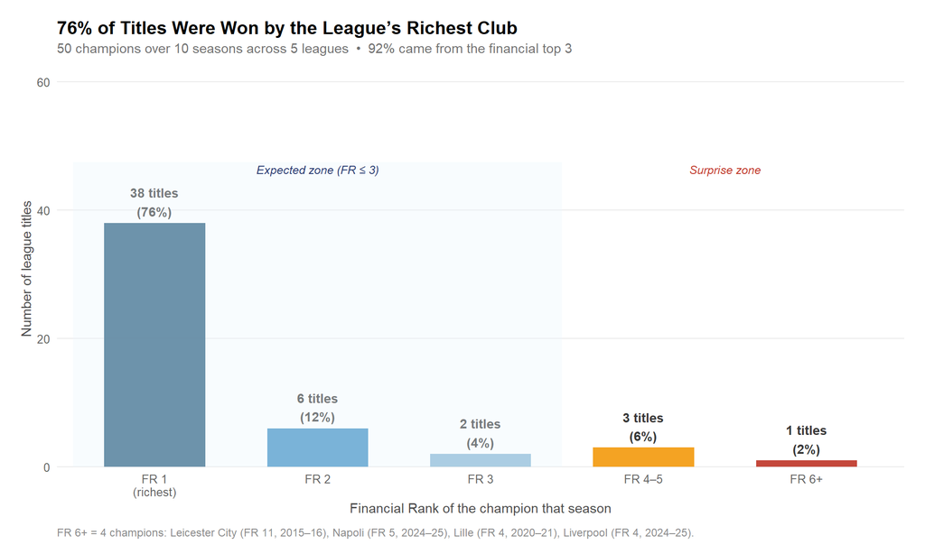

Distribution of Financial Rank among all 50 league champions across 10 seasons and 5 leagues. The dominance of Financial Rank 1 is striking.

Of the 4 champions from outside the top three, three (Napoli at Financial Rank 5, Lille at Financial Rank 4, and Liverpool at Financial Rank 4) were only barely outside the expected zone and within a normal range of variation. Only Leicester City, at Financial Rank 11, is a genuine statistical outlier among the champions, confirming the finding above.

# 6 Robustness

## 6.1 Why Run the Same Analysis Under Different Conditions

A single result, however strong, could in principle be an artefact of one particular time period, one particular league, or one particular sport’s institutional rules. A robustness check re-runs the same core analysis under a different slice of the data, or on a genuinely different dataset, to see whether the same conclusion still holds. If it does, that is strong evidence the finding reflects something real about how money and performance relate, rather than a coincidence of the specific sample used. The checks summarised below were originally carried out on the position based specification developed earlier in this project (full detail, including formal statistical tests such as checks for heteroskedasticity, a situation in which the spread of a model’s errors is not constant across the range of predictions, and the corresponding use of robust standard errors, standard error estimates adjusted to remain valid even when that spread is not constant, is preserved in the Appendix). The fact that the same pattern holds under a different outcome variable entirely (points per game modelled with a generalized additive model, the approach used throughout this report) makes the overall finding more trustworthy still, since it means the conclusion does not depend on the specific choice of how success is measured.

## 6.2 Consistency Across Leagues

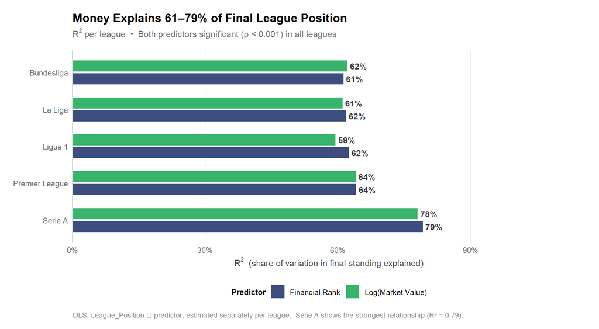

R-squared (variance explained in final position) by Financial Rank, broken down by league.

## 6.3 Stability Over the Decade Studied

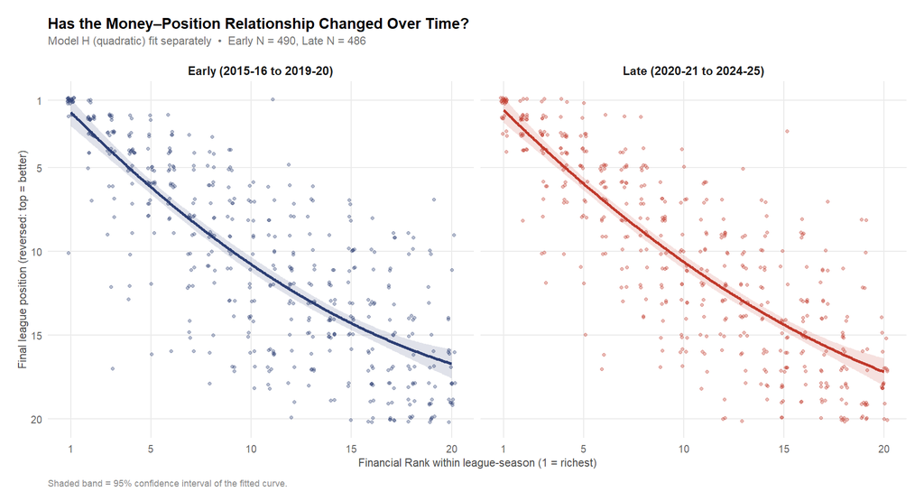

Financial Rank vs. League Position, fit separately for the Early (2015-16 to 2019-20) and Late (2020-21 to 2024-25) halves of the decade. The two fitted curves are visually almost indistinguishable.

Splitting the ten seasons into two independent five-season halves and re-fitting the model separately on each half produces two fitted curves that overlap almost completely (Early period Financial Rank slope 1.25, Late period slope 1.21; a formal test of whether the two slopes differ gives p = 0.797, far from statistically significant). The relationship between financial rank and performance has neither strengthened nor weakened across the decade studied.

## 6.4 Transfer Market Inflation

Squad market values rose substantially over the decade studied: indexed to a 2019-20 base of 1.00, the average squad value across the five leagues stood at 0.59 in 2015-16 and had risen to 1.30 by 2024-25. This raises a natural question: does that inflation distort Financial Rank, or any of the results built on it?

By construction, it does not. Financial Rank is computed separately within each league-season: every squad in the same league-season is ranked against the other squads in that same league-season only, never against squads from a different year. Because inflation raises all squad values within a given league-season together, it scales every club by roughly the same factor at the same point in time. A within-season rank is unaffected by a common scaling: if every value in a league-season is multiplied by the same number, the order from richest to poorest does not change, so neither does the rank.

This was also checked directly rather than left as a theoretical argument. Every squad market value in the corrected dataset was deflated by the yearly inflation index, and Financial Rank was recomputed from those deflated values for all 976 team-seasons. The recomputed ranks were identical to the original ranks in every single case: zero rank changes across the full corrected dataset. This directly addresses a question raised after the presentation of this project, whether the headline result could be an artefact of rising transfer market prices over the decade rather than a genuine, stable relationship between financial strength and sporting performance; the answer is that it is not.

## 6.5 Beyond Football: A Salary-Capped League

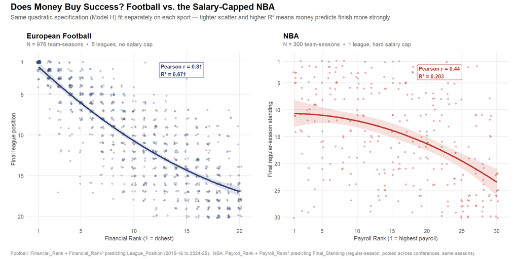

Side by side comparison: Financial Rank vs. League Position (European football, no salary cap) and Payroll Rank vs. Final Standing (NBA, hard salary cap).

The same quadratic specification, fit on ten seasons of NBA data (a professional basketball league that, unlike European football, operates under a hard salary cap limiting how much any one team can spend on player wages), confirms that the money predicts success pattern is not unique to football: Payroll Rank significantly predicts NBA final standing. But the relationship is far weaker under the NBA’s cap (R squared = 0.2027, r = 0.4364) than in football’s largely unrestricted spending environment (R squared = 0.6713, r = 0.8127), and only 50% of NBA titles in the period went to a top three payroll team, versus 92% in football. This is indirect evidence that deliberate cap style mechanisms, such as the salary cap tested here or Financial Fair Play in European football, can meaningfully weaken, without eliminating, the link between spending and winning.

**Points per game, checked against total points, was already tested and held.** An earlier stage of this project also re-fit the quadratic specification with total points won as the outcome instead of final position, and found that Leicester City 2015-16 remained the single largest statistical anomaly under that outcome too. Combined with the results above, the core finding has now been confirmed under three different outcome variables (position, points, and points per game) and two different functional forms (a fixed quadratic curve and a learned smooth curve), in addition to the time split and cross sport checks in this section.

# 7 Conclusions

This report set out to determine whether financial strength predicts sporting success in Europe’s five major football leagues, using points per game as the outcome and a generalized additive model to let the data determine the shape of that relationship. The answer is unambiguous: yes, and very strongly so. Each finding below is written to stand on its own.

**Finding 1: Financial Rank explains most of the variation in points per game, and does so better than any fixed-shape alternative tried.** The generalized additive model achieves a deviance explained of 0.707 (71%) and the lowest AIC of the three specifications compared, 75.32. The same underlying relationship, measured the original way through final league position, gives a Pearson correlation of r = 0.813 and R squared = 0.671, confirming the result under an earlier, independently developed specification.

**Finding 2: The relationship genuinely curves, and the curve is more nuanced than a simple parabola.** The generalized additive model’s effective degrees of freedom of 6.3, well above the value of 1 that would indicate no curvature at all, confirms real, non-trivial curvature in how financial rank relates to performance, while also showing that the curve is more flexible than the single symmetric bend a fixed quadratic term allows. In plain terms, the gap between the richest and second richest club matters more than the gap between two closely matched mid table clubs, and the shape of that pattern is best estimated directly from the data rather than assumed in advance.

**Finding 3: The relationship is consistent across leagues and stable over time.** Financial Rank predicts final position with an R squared between 0.61 and 0.79 in every one of the five leagues studied, and splitting the decade into two independent five-season halves produces statistically indistinguishable fitted curves (p = 0.797 for the test of whether the slopes differ). Financial dominance is a stable, general feature of European football during the period studied, not a league-specific or recent phenomenon.

**Finding 5: The result survives a battery of independent robustness checks.** The relationship holds within every individual league, across both halves of the decade studied, under three different outcome variables (position, points, and points per game), and under two different functional forms (a fixed quadratic curve and a learned smooth curve). No single check weakens the core finding.

**Finding 6: The pattern generalises beyond football, but a salary cap visibly weakens it.** The same specification fit on NBA data confirms that money predicts success is not football-specific, but the relationship is far weaker under the NBA’s hard salary cap (R squared = 0.2027) than in football’s largely unrestricted spending environment (R squared = 0.6713). This is indirect evidence that deliberate cap style mechanisms can meaningfully loosen, without eliminating, the link between spending and winning.

## 7.1 Limitations and Future Directions

[output not shown]

Table 5: Study limitations and suggested future extensions.

# 8 Appendix

## 8.1 Full Coefficient Table (Models A and H)

| Model | Term | Estimate | Std. Error | t / z | p-value |
| --- | --- | --- | --- | --- | --- |
| A | (Intercept) | 1.9278 | 0.2190 | 8.804 | < 0.001 *** |
|  | Financial_Rank | 0.8127 | 0.0187 | 43.536 | < 0.001 *** |
| H | (Intercept) | 0.4172 | 0.3441 | 1.212 | 0.2257 |
|  | Financial_Rank | 1.2309 | 0.0765 | 16.093 | < 0.001 *** |
|  | I(Financial_Rank^2) | -0.0202 | 0.0036 | -5.633 | < 0.001 *** |

Table 6: Full regression coefficient table, Models A (linear) and H (quadratic).

## 8.2 Model H Quadratic Coefficients, Position Outcome (Detailed)

| Term | Estimate | SE | t-value | p-value | CI lower | CI upper |
| --- | --- | --- | --- | --- | --- | --- |
| Intercept | 0.4172 | 0.3441 | 1.212 | 2.257e-01 | -0.2573 | 1.0916 |
| Financial Rank (b1) | 1.2309 | 0.0765 | 16.093 | 7.648e-52 | 1.0810 | 1.3808 |
| Financial Rank squared (b2) | -0.0203 | 0.0036 | -5.633 | 2.323e-08 | -0.0273 | -0.0132 |

Table 7: Model H (Position explained by Financial Rank plus Financial Rank squared) full coefficient table with 95 percent confidence intervals.

## 8.3 Position Model Diagnostics: Residual Plot and Heteroskedasticity Tests

Because final league position is still reported alongside points per game in this report (as corroborating context, not as the primary outcome), the diagnostic checks recommended for any continued use of an ordinal outcome are reproduced here in full, rather than only referenced.

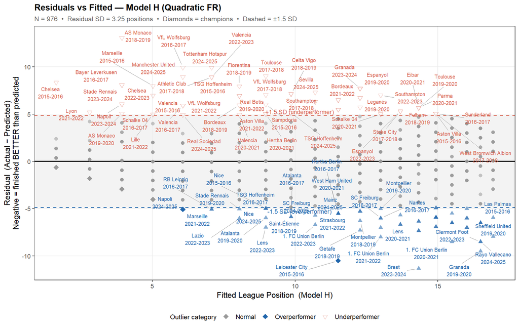

Residuals vs fitted values, Model H (League Position explained by Financial Rank plus Financial Rank squared). The shaded band marks ordinary variation; labelled points lie beyond 1.5 residual standard deviations.

| Test | Statistic | Parameter | p-value |
| --- | --- | --- | --- |
| Breusch-Pagan (heteroskedasticity) | 45.52 | 6 | 3.683e-08 |
| Durbin-Watson (autocorrelation) | 1.18 |  | 6.094e-39 |

Table 8: Breusch-Pagan test for heteroskedasticity and Durbin-Watson test for autocorrelation, Model D (League Position explained by log squad value, league, and season index).

Both tests reject their null hypothesis at p < 0.001: the constant-variance and independent-errors assumptions behind an ordinary least squares model do not strictly hold for a position-based specification. This is exactly the kind of limited interpretability the recommendation to critically analyze position-based results anticipates, and it is a second, independent reason (beyond position’s ordinal, non-continuous scale) that this report treats points per game and the generalized additive model as primary, using position only as corroborating evidence. As a check on how much this distorts inference, Model D was refit with heteroskedasticity-robust (HC1) standard errors:

| Term | Estimate | SE (OLS) | SE (HC1 robust) | t-value | p-value |
| --- | --- | --- | --- | --- | --- |
| (Intercept) | -0.2152 | 0.4049 | 0.3712 | -0.5796 | 5.623e-01 |
| Log_Normalized_Value | -5.9663 | 0.1439 | 0.1227 | -48.6367 | 2.796e-262 |
| LeagueLa Liga | -0.2012 | 0.3507 | 0.3547 | -0.5671 | 5.708e-01 |
| LeagueLigue 1 | -1.1028 | 0.3542 | 0.3587 | -3.0744 | 2.168e-03 |
| LeaguePremier League | 4.0859 | 0.3573 | 0.3533 | 11.5660 | 4.500e-29 |
| LeagueSerie A | 2.7888 | 0.3521 | 0.3119 | 8.9426 | 1.890e-18 |
| Season_Index | 0.1059 | 0.0381 | 0.0387 | 2.7364 | 6.326e-03 |

Table 9: Model D coefficients with ordinary vs. heteroskedasticity-robust (HC1) standard errors. Conclusions about which terms are statistically significant are unchanged.

The robust standard errors are close to the ordinary ones for every term, and no term crosses the conventional 0.05 significance threshold in either direction as a result of the correction. The substantive conclusions drawn from the position-based specification are therefore not an artefact of the detected heteroskedasticity, even though, as a matter of statistical principle, points per game remains the more appropriate outcome variable for the reasons given in the Methodology section.

## 8.4 Points-Per-Game Model Comparison Table (Full Precision)

| Model | Outcome | N | R squared / deviance explained | AIC | Effective degrees of freedom |
| --- | --- | --- | --- | --- | --- |
| H: Quadratic (PPG) [reference] | Points_Per_Game | 976 | 0.6958 | 100.10 |  |
| Linear (PPG) | Points_Per_Game | 976 | 0.6524 | 228.50 |  |
| GAM (PPG) | Points_Per_Game | 976 | 0.7065 | 75.32 | 6.303 |

Table 10: Linear, quadratic, and generalized additive model comparison for points per game, at full precision, from this report’s underlying GAM revision output.

## 8.5 Whole-Project Model Evolution Table

| Model | Outcome | N | R squared | AIC |
| --- | --- | --- | --- | --- |
| A: Linear baseline | League_Position | 976 | 0.6606 | 5104.4 |
| H: Quadratic (position) | League_Position | 976 | 0.6713 | 5075.1 |
| H: Quadratic (points) | Points | 976 | 0.6776 | 7234.6 |
| H: Quadratic (PPG) | Points_Per_Game | 976 | 0.6958 | 100.1 |

Table 11: Every position, points, and points-per-game specification fitted across the whole project, from this report’s whole-project model evolution output.

## 8.6 Analysis Script Inventory

The complete, runnable source code for this project is available at **https://github.com/ShawnMuktadir/Money-and-Success-in-Football**. Readers who want to reproduce or extend this analysis should start there. The table below lists every analysis script (scripts 01-12 are in `RScripts/`, scripts 13-16 are in `extensions/scripts/`), in run order, and what each one produces.

[output not shown]

Table 12: Analysis scripts and their outputs, in run order, shown as two side-by-side Script/Produces columns for width.

## 8.7 Session Information

| R version | 4.5.3 |
| --- | --- |
| Platform | Windows 11 x64 (build 26200) |
| Date knitted | 2026-07-21 |
| Key packages | dplyr, ggplot2, broom, kableExtra, ggrepel, mgcv |

**Package citations.** Wood, S.N. (2017). *Generalized Additive Models* (2nd ed.), Chapman and Hall/CRC (mgcv). Wickham, H. (2016). *ggplot2: Elegant Graphics for Data Analysis*, Springer. Wickham et al., *dplyr* and *tidyr*, https://tidyverse.org. Robinson et al., *broom*, https://broom.tidymodels.org. Zhu, H., *kableExtra*, https://haozhu233.github.io/kableExtra/.

*Report generated with R Markdown. Data sources: ESPN FC (league standings), Transfermarkt (squad market values). All analysis scripts are available in the project repository. For questions, contact: mdmuktadir0611@gmail.com*